# UNICEF Data Visualizations

Author

Muhammed Areeb Syed

Published

April 27, 2025

# Introduction

This report leverages data from the combined CSV files, which include various indicators and metadata, to construct a comprehensive analysis of the relationships between key variables. By examining economic, health, and social dimensions through interactive visualizations, the report aims to uncover significant trends, explore hidden patterns, and identify actionable insights.

The analysis directly contributes to understanding how different factors such as economic performance, health outcomes, and social indicators influence each other. Despite global progress, disparities still exist across various regions, and understanding the interplay of these factors is crucial for addressing underlying inequalities. This report highlights how insights from data can be used to inform policy decisions and promote more targeted interventions for improving public health and social welfare.

# Load Libraries

```python
!pip install geopandas pygeos --quiet
!pip install --upgrade geopandas --quiet

import pandas as pd
import plotnine as p9
import geopandas as gpd
import plotly.express as px
from IPython.display import display
```

# Load Datasets

```python
metadata = pd.read_csv('unicef_metadata.csv')
indicator2 = pd.read_csv('unicef_indicator_2.csv')

metadata = metadata.dropna(subset=['Life expectancy at birth, total (years)', 'GDP per capita (constant 2015 US$)'])
indicator2 = indicator2[indicator2['indicator'] == 'Proportion of schools with basic hygiene services']
```

# Life Expectancy vs GDP per Capita

This graph highlights the correlation between life expectancy and GDP per capita across different countries. It showcases how wealthier nations tend to have higher life expectancy, with a logarithmic scale on the GDP axis to illustrate significant variations more clearly. The regression line helps depict the overall trend of how higher income correlates with better life expectancy.

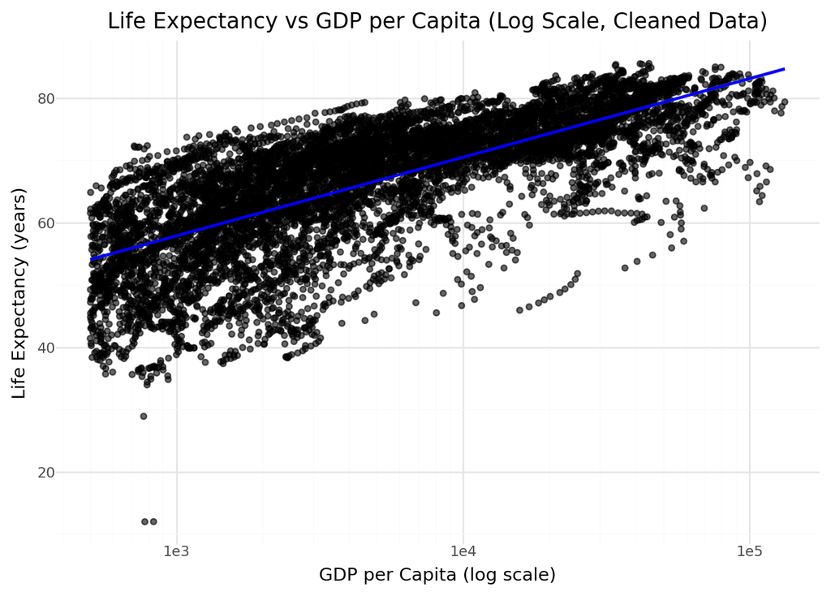

```python
metadata_filtered = metadata[
    (metadata['GDP per capita (constant 2015 US$)'] > 500) &
    (metadata['GDP per capita (constant 2015 US$)'] < 150000)
]

plot1 = (
    p9.ggplot(metadata_filtered, p9.aes(x='GDP per capita (constant 2015 US$)', y='Life expectancy at birth, total (years)'))
    + p9.geom_point(alpha=0.6)
    + p9.geom_smooth(method='lm', color='blue')
    + p9.scale_x_continuous(trans='log10')
    + p9.labs(
        title="Life Expectancy vs GDP per Capita (Log Scale, Cleaned Data)",
        x="GDP per Capita (log scale)",
        y="Life Expectancy (years)"
    )
    + p9.theme_minimal()
)

display(plot1.draw())
```

# Hospital Beds Availability

This chart demonstrates the availability of hospital beds in various countries. The data sheds light on global disparities in healthcare infrastructure, emphasizing how some nations have limited resources to provide adequate healthcare. The visualization helps to underline the importance of improving healthcare facilities worldwide to meet public health demands.

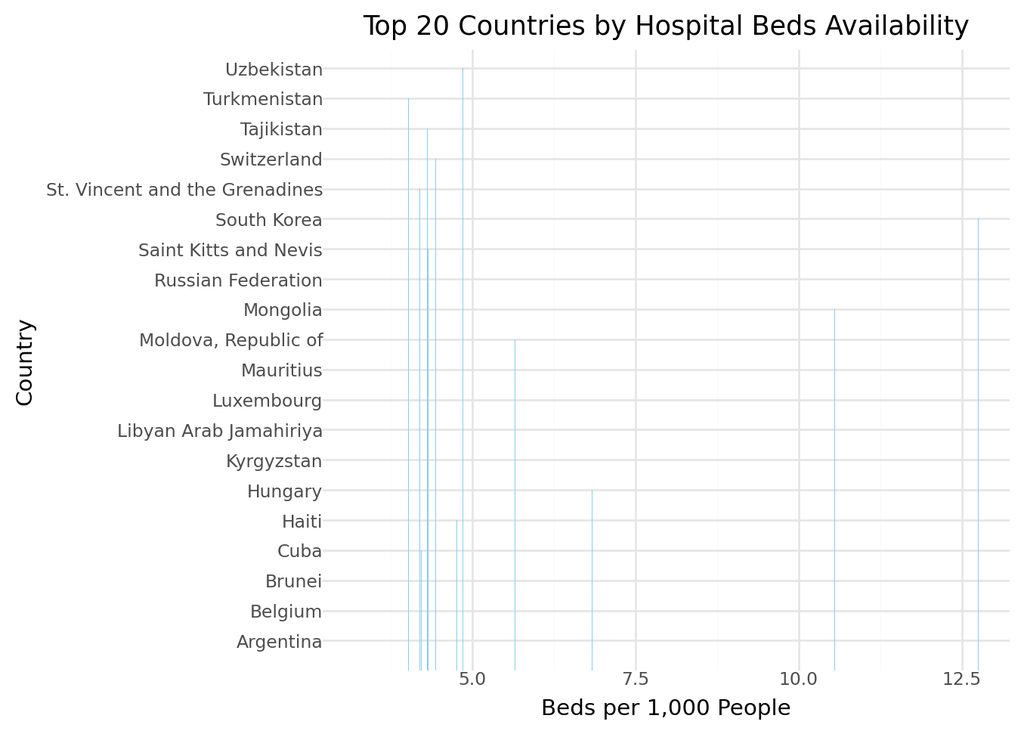

```python
beds_data = metadata.dropna(subset=['Hospital beds (per 1,000 people)'])
beds_latest = beds_data[beds_data['year'] == beds_data['year'].max()]

top_beds = beds_latest.sort_values('Hospital beds (per 1,000 people)', ascending=False).head(20)

plot2 = (
    p9.ggplot(top_beds, p9.aes(x='Hospital beds (per 1,000 people)', y='country'))
    + p9.geom_col(fill='skyblue')
    + p9.labs(
        title="Top 20 Countries by Hospital Beds Availability",
        x="Beds per 1,000 People",
        y="Country"
    )
    + p9.theme_minimal()
)

display(plot2.draw())
```

# GDP Growth Trend for Afghanistan

This graph tracks the GDP growth trends in Afghanistan over recent years, showcasing periods of growth and stagnation. It reflects the economic challenges faced by the country, offering insights into how global factors, internal conflicts, and policy changes have impacted its economic stability.

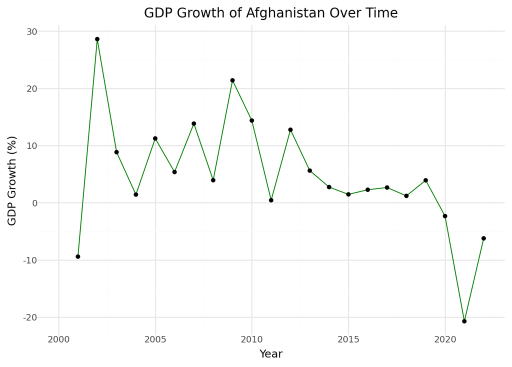

```python
afghanistan = metadata[metadata['country'] == 'Afghanistan']

plot3 = (
    p9.ggplot(afghanistan, p9.aes(x='year', y='GDP growth (annual %)'))
    + p9.geom_line(color='green')
    + p9.geom_point()
    + p9.labs(
        title="GDP Growth of Afghanistan Over Time",
        x="Year",
        y="GDP Growth (%)"
    )
    + p9.theme_minimal()
)

display(plot3.draw())
```

# Hygiene Facilities in Schools

This chart reveals the percentage of schools across various countries with hygiene facilities. It underscores the importance of maintaining sanitation in educational institutions, especially in the wake of global health challenges. Countries with lower access to hygiene facilities are highlighted to advocate for urgent policy action to improve hygiene standards in schools.

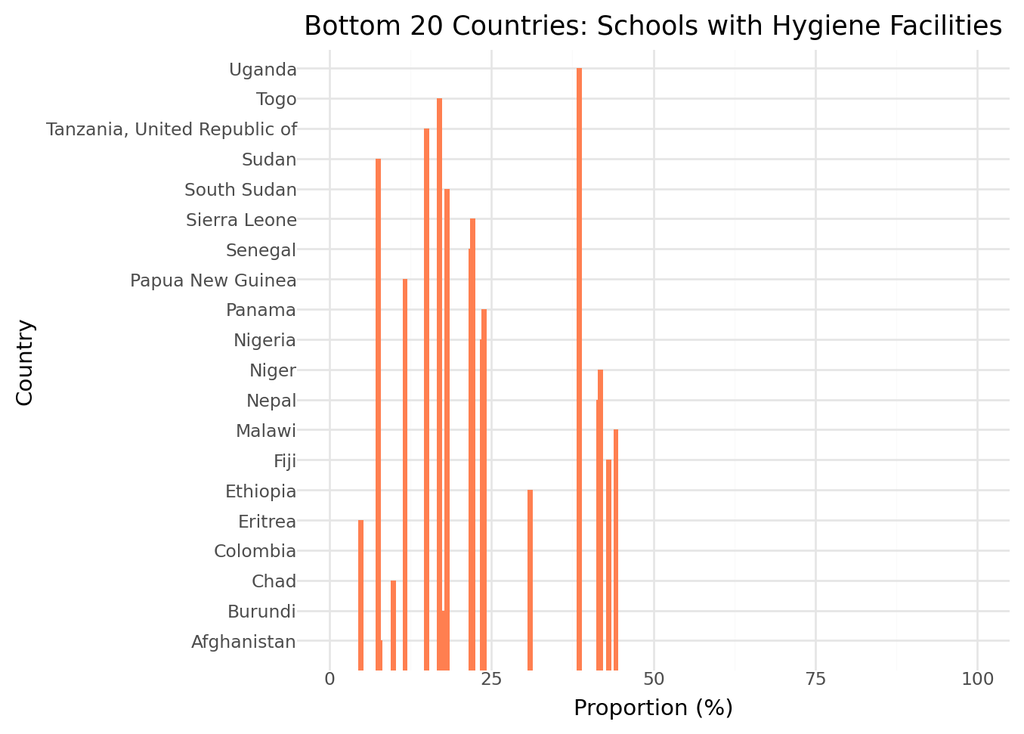

```python
indicator2_latest = indicator2[indicator2['year'] == indicator2['year'].max()]
bottom_hygiene = indicator2_latest.sort_values('obs_value', ascending=True).head(20)

plot4 = (
    p9.ggplot(bottom_hygiene, p9.aes(x='obs_value', y='country'))
    + p9.geom_col(fill='coral', width=0.8)
    + p9.labs(
        title="Bottom 20 Countries: Schools with Hygiene Facilities",
        x="Proportion (%)",
        y="Country"
    )
    + p9.scale_x_continuous(limits=[0, 100])
    + p9.theme_minimal()
)

display(plot4.draw())
```